# Midterm 1

Brian Roepke

October 30, 2020

# Data 104 Midterm

The sample dataset contains obfuscated Google Analytics 360 data from the Google Merchandise Store, a real ecommerce store that sells Google branded merchandise. The dataset was pulled using Google’s BigQuery.

The following are the definitions of the fields from Google Analytics:

- **date** - session in YYYYMMDD format
- **userID** - (eg: fullVisitorId) ; The unique visitor ID (also known as client ID).
- **sessionID** - (eg: visitId); Identifier for this session. Only unique to the user. For a completely unique ID, you use a combination of fullVisitorId and visitId.
- **session** - (eg: visitNumber); The session number for this user. If this is the first session, then this is set to 1.
- **pageviews** - Total number of pageviews within the session.
- **newVisits** - Total number of new users in session (for convenience). If this is the first visit, this value is 1, otherwise it is null.
- **transactions** - Total number of ecommerce transactions within the session.
- **visits** - This value is 1 for sessions with interaction events. The value is null if there are no interaction events in the session
- **totalTransactionRevenue** - Total transaction revenue, expressed as the value passed to Analytics multiplied by 10^6 (e.g., 2.40 would be given as 2400000)
- **browser** - browser used (e.g., “Chrome” or “Firefox”).
- **deviceCategory** - Type of device (Mobile, Tablet, Desktop).
- **country** - Country from which sessions originated
- **region** - Region from which sessions originate. In the U.S., a region is a state, such as New York.
- **hitNumber** - Sequence of pages that a user looked at within one session. (eg: the sequenced hit number). For the first hit of each session, this is set to 1.
- **pagePath** - URL path of the page.

```r
# plotting and pipes - tidyverse
library(ggplot2)
library(dplyr, warn.conflicts = FALSE)
options(dplyr.summarise.inform = FALSE) # Suppress summarise info
suppressPackageStartupMessages(library(tidyverse)) # suppress startup message
library(lubridate, warn.conflicts = FALSE)
library(scales)
library(aod)

# don't use scientific notation (for the userID field)
options(scipen=999)
```

```r
ga <- read.csv("bq-results.csv", colClasses=c("userID"="character"))
```

# Data Load & Prep

```r
ga$date <- as.character(ga$date)
ga$date <- as.Date(ga$date, "%Y%m%d")
ga$browser <- as.factor(ga$browser)
ga$deviceCategory <- as.factor(ga$deviceCategory)
ga$country <- as.factor(ga$country)
ga$region <- as.factor(ga$region)

# Rescale totalTransactionRevenue by dividing by 1 million
ga$totalTransactionRevenue <- ga$totalTransactionRevenue / 1e+6

# Columns to remove - Not needed for the analysis.  Removing these will make the data a little simpler
ga$hitNumber <- NULL
ga$pagePath <- NULL

# Clean up some of the values to more useful settings
ga$region[ga$region == "not available in demo dataset"] <- NA
ga$region[ga$region == "(not set)"] <- NA
ga$transactions[is.na(ga$transactions)] <- 0
# ga$totalTransactionRevenue[is.na(ga$totalTransactionRevenue)] <- 0

str(ga)
```

```
## 'data.frame':    281493 obs. of  13 variables:
##  $ date                   : Date, format: "2017-07-09" "2017-07-19" ...
##  $ userID                 : chr  "0000062267706107999" "0000085059828173212" "0000436683523507380" "0000436683523507380" ...
##  $ sessionID              : int  1499645960 1500505105 1500504900 1500504900 1500989127 1500989127 1500989127 1500989127 1500989127 1500989127 ...
##  $ session                : int  1 1 1 1 2 2 2 2 2 2 ...
##  $ pageviews              : int  1 1 2 2 8 8 8 8 8 8 ...
##  $ newVisits              : int  1 1 1 1 NA NA NA NA NA NA ...
##  $ transactions           : num  0 0 0 0 0 0 0 0 0 0 ...
##  $ visits                 : int  1 1 1 1 1 1 1 1 1 1 ...
##  $ totalTransactionRevenue: num  NA NA NA NA NA NA NA NA NA NA ...
##  $ browser                : Factor w/ 30 levels "(not set)","[Use default User-agent string] LIVRENPOCHE",..: 9 25 9 9 9 9 9 9 9 9 ...
##  $ deviceCategory         : Factor w/ 3 levels "desktop","mobile",..: 1 2 1 1 1 1 1 1 1 1 ...
##  $ country                : Factor w/ 190 levels "(not set)","Afghanistan",..: 25 182 182 182 182 182 182 182 182 182 ...
##  $ region                 : Factor w/ 131 levels "(not set)","Alberta",..: NA 45 80 80 80 80 80 80 80 80 ...
```

```r
head(ga)
```

|  | date | userID | sessionID | session | pageviews | newVisits | transactions | visits | totalTransactionRevenue | browser | deviceCategory | country | region |
| --- | --- | --- | --- | --- | --- | --- | --- | --- | --- | --- | --- | --- | --- |
| 1 | 2017-07-09 | 0000062267706107999 | 1499645960 | 1 | 1 | 1 | 0 | 1 | NA | Chrome | desktop | Brazil | NA |
| 2 | 2017-07-19 | 0000085059828173212 | 1500505105 | 1 | 1 | 1 | 0 | 1 | NA | Safari | mobile | United States | Illinois |
| 3 | 2017-07-19 | 0000436683523507380 | 1500504900 | 1 | 2 | 1 | 0 | 1 | NA | Chrome | desktop | United States | New York |
| 4 | 2017-07-19 | 0000436683523507380 | 1500504900 | 1 | 2 | 1 | 0 | 1 | NA | Chrome | desktop | United States | New York |
| 5 | 2017-07-25 | 0000436683523507380 | 1500989127 | 2 | 8 | NA | 0 | 1 | NA | Chrome | desktop | United States | New York |
| 6 | 2017-07-25 | 0000436683523507380 | 1500989127 | 2 | 8 | NA | 0 | 1 | NA | Chrome | desktop | United States | New York |

```r
tail(ga)
```

|  | date | userID | sessionID | session | pageviews | newVisits | transactions | visits | totalTransactionRevenue | browser | deviceCategory | country | region |
| --- | --- | --- | --- | --- | --- | --- | --- | --- | --- | --- | --- | --- | --- |
| 281488 | 2017-07-25 | 9999430912254902219 | 1500972450 | 1 | 24 | 1 | 0 | 1 | NA | Chrome | desktop | Singapore | NA |
| 281489 | 2017-07-25 | 9999430912254902219 | 1500972450 | 1 | 24 | 1 | 0 | 1 | NA | Chrome | desktop | Singapore | NA |
| 281490 | 2017-07-25 | 9999430912254902219 | 1500972450 | 1 | 24 | 1 | 0 | 1 | NA | Chrome | desktop | Singapore | NA |
| 281491 | 2017-07-25 | 9999430912254902219 | 1500972450 | 1 | 24 | 1 | 0 | 1 | NA | Chrome | desktop | Singapore | NA |
| 281492 | 2017-07-05 | 9999594748540438502 | 1499262993 | 2 | 1 | NA | 0 | 1 | NA | Safari | desktop | United States | New York |
| 281493 | 2017-07-01 | 9999944980984230465 | 1498900256 | 1 | 1 | 1 | 0 | 1 | NA | Chrome | desktop | India | Telangana |

```r
ga %>%
  distinct() %>%
  select(date, session, pageviews, transactions,
         totalTransactionRevenue, browser,
         deviceCategory, country, region) %>%
  summary()
```

```
##       date               session        pageviews        transactions
##  Min.   :2017-07-01   Min.   :  1.0   Min.   :  1.000   Min.   :0.00000
##  1st Qu.:2017-07-09   1st Qu.:  1.0   1st Qu.:  1.000   1st Qu.:0.00000
##  Median :2017-07-17   Median :  1.0   Median :  1.000   Median :0.00000
##  Mean   :2017-07-16   Mean   :  2.2   Mean   :  3.786   Mean   :0.01502
##  3rd Qu.:2017-07-25   3rd Qu.:  1.0   3rd Qu.:  4.000   3rd Qu.:0.00000
##  Max.   :2017-08-01   Max.   :395.0   Max.   :186.000   Max.   :4.00000
##
##  totalTransactionRevenue              browser      deviceCategory
##  Min.   :    2.99        Chrome           :51854   desktop:47322
##  1st Qu.:   28.36        Safari           :13959   mobile :23832
##  Median :   49.21        Firefox          : 2871   tablet : 3198
##  Mean   :  157.94        Internet Explorer: 1580
##  3rd Qu.:  103.37        Edge             : 1017
##  Max.   :25249.26        Android Webview  :  909
##  NA's   :73278           (Other)          : 2162
##            country             region
##  United States :33957   California:10331
##  India         : 4888   New York  : 2239
##  United Kingdom: 3974   England   : 1266
##  Canada        : 2496   Texas     :  934
##  Japan         : 1790   Washington:  921
##  Germany       : 1785   (Other)   :14757
##  (Other)       :25462   NA's      :43904
```

These summary statistics aren’t as useful given the data structure, which will be explained next.

## EDA for Single UserID and single SessionID

The following explores the structure of this data. Each row in this doesn’t represent a different user or an extra session. So quickly explore and explain that. First, by looking at what a single user/session data looks like.

```r
ga %>%
  filter(userID == "0014262055593378383" & sessionID == 1499123682) %>%
  head(n = 50)
```

|  | date | userID | sessionID | session | pageviews | newVisits | transactions | visits | totalTransactionRevenue | browser | deviceCategory | country | region |
| --- | --- | --- | --- | --- | --- | --- | --- | --- | --- | --- | --- | --- | --- |
| 1 | 2017-07-03 | 0014262055593378383 | 1499123682 | 4 | 30 | NA | 2 | 1 | 50.21 | Chrome | desktop | United States | NA |
| 2 | 2017-07-03 | 0014262055593378383 | 1499123682 | 4 | 30 | NA | 2 | 1 | 50.21 | Chrome | desktop | United States | NA |
| 3 | 2017-07-03 | 0014262055593378383 | 1499123682 | 4 | 30 | NA | 2 | 1 | 50.21 | Chrome | desktop | United States | NA |
| 4 | 2017-07-03 | 0014262055593378383 | 1499123682 | 4 | 30 | NA | 2 | 1 | 50.21 | Chrome | desktop | United States | NA |
| 5 | 2017-07-03 | 0014262055593378383 | 1499123682 | 4 | 30 | NA | 2 | 1 | 50.21 | Chrome | desktop | United States | NA |
| 6 | 2017-07-03 | 0014262055593378383 | 1499123682 | 4 | 30 | NA | 2 | 1 | 50.21 | Chrome | desktop | United States | NA |
| 7 | 2017-07-03 | 0014262055593378383 | 1499123682 | 4 | 30 | NA | 2 | 1 | 50.21 | Chrome | desktop | United States | NA |
| 8 | 2017-07-03 | 0014262055593378383 | 1499123682 | 4 | 30 | NA | 2 | 1 | 50.21 | Chrome | desktop | United States | NA |
| 9 | 2017-07-03 | 0014262055593378383 | 1499123682 | 4 | 30 | NA | 2 | 1 | 50.21 | Chrome | desktop | United States | NA |
| 10 | 2017-07-03 | 0014262055593378383 | 1499123682 | 4 | 30 | NA | 2 | 1 | 50.21 | Chrome | desktop | United States | NA |

[output cut: 20 more lines]

We can see that a single user’s activity, with 30 pageviews, results in 30 rows in the data. Each row contains the same information except `hitNumber` and `pagePath` (which have been dropped from the dataset already since they will not be used in the analysis.)

### Distinct User Activity

Using that same user, showing all of their activity but with the duplicate rows removed. This will then contain a single row for each different session of activity.

```r
ga %>%
  filter(userID == "0014262055593378383") %>%
  distinct() %>%
  select(date, session, pageviews, transactions,
         totalTransactionRevenue, browser,
         deviceCategory, country, region) %>%
  summary()
```

```
##       date               session    pageviews     transactions
##  Min.   :2017-07-03   Min.   :4   Min.   : 1.0   Min.   :0.0
##  1st Qu.:2017-07-14   1st Qu.:5   1st Qu.: 1.0   1st Qu.:0.0
##  Median :2017-07-15   Median :6   Median : 8.0   Median :0.0
##  Mean   :2017-07-13   Mean   :6   Mean   :13.2   Mean   :0.6
##  3rd Qu.:2017-07-18   3rd Qu.:7   3rd Qu.:26.0   3rd Qu.:1.0
##  Max.   :2017-07-19   Max.   :8   Max.   :30.0   Max.   :2.0
##
##  totalTransactionRevenue                                        browser
##  Min.   :24.58           Chrome                                     :5
##  1st Qu.:30.99           (not set)                                  :0
##  Median :37.40           [Use default User-agent string] LIVRENPOCHE:0
##  Mean   :37.40           0                                          :0
##  3rd Qu.:43.80           Amazon Silk                                :0
##  Max.   :50.21           Android Browser                            :0
##  NA's   :3               (Other)                                    :0
##  deviceCategory          country                region
##  desktop:5      United States:5   (not set)        :0
##  mobile :0      (not set)    :0   Alberta          :0
##  tablet :0      Afghanistan  :0   Amman Governorate:0
##                 Albania      :0   Andalusia        :0
##                 Algeria      :0   Ankara           :0
##                 Andorra      :0   (Other)          :0
##                 (Other)      :0   NA's             :5
```

## Location Analysis

[figure not shown]

```r
ga %>%
  distinct() %>%
  count(country, sort = TRUE)  %>%
  mutate(country = reorder(country, n))  %>%
  slice_max(order_by=country, n = 10) %>%

  ggplot(aes(x = country, y = n)) +
  geom_col() +
  coord_flip() +
  theme_minimal() +
  labs(x = "Count",
       y = "Country",
       title = "Top Countries of Users")
```

[figure not shown]

```r
ga %>%
  distinct() %>%
  filter(transactions > 0) %>%
  count(country, sort = TRUE)  %>%
  mutate(country = reorder(country, n))  %>%
  slice_max(order_by=country, n = 10) %>%

  # Create a Colum chart of top 10
  ggplot(aes(x = country, y = n)) +
  geom_col() +
  coord_flip() +
  theme_minimal() +
  labs(x = "Count",
       y = "Country",
       title = "Top Countries of Users Who Made a Transaction")
```

When you filter out users who didn’t make a purchase, you can see that many transactions come from the US, with Canada second.

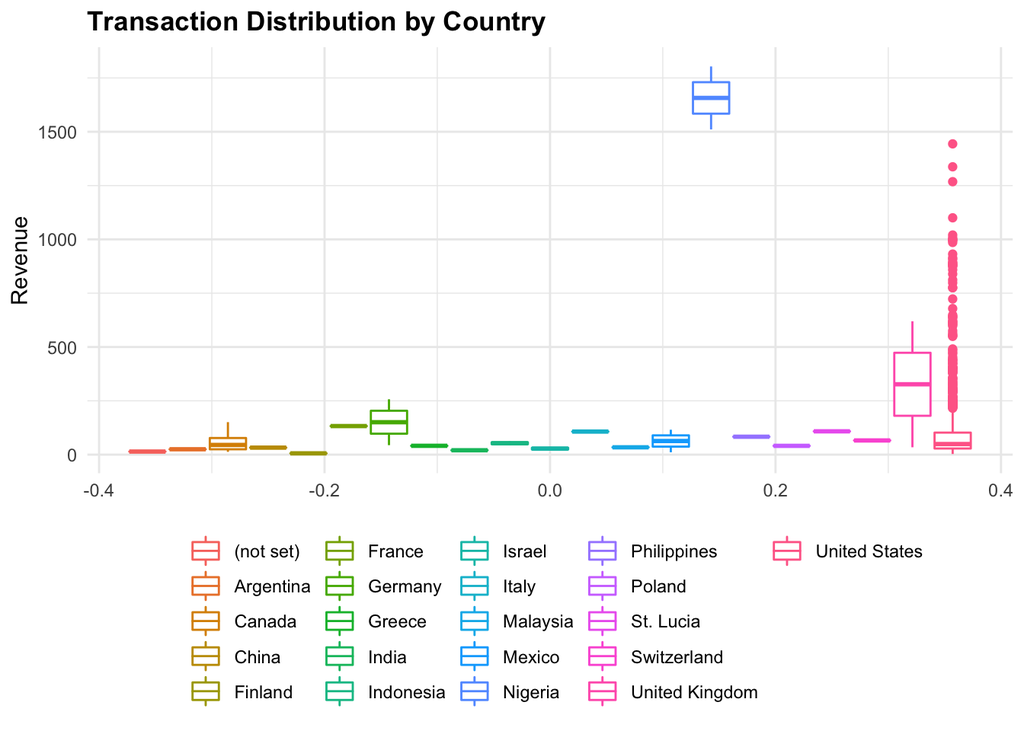

```r
ga %>%
  distinct() %>%
  filter(transactions > 0 & totalTransactionRevenue < 2000) %>%
    ggplot(aes(totalTransactionRevenue, color = country)) +
    geom_boxplot() +
    labs(title = "Transaction Distribution by Country",
         x = "Revenue",
         y = NULL) +
    theme_minimal() +
    theme(
      legend.title = element_blank(),
      legend.position = "bottom",
      plot.title = element_text(face = "bold")) +
  coord_flip()
```

**Note:** *The max transaction size here has been filtered to be less than 2,000, taking out a two the outliers.*

## EDA of Transactions

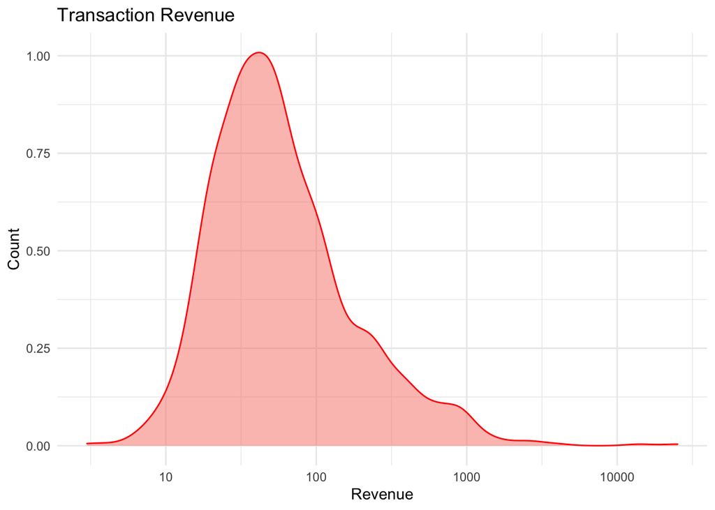

```r
ga %>%
  distinct() %>%
  filter(transactions > 0) %>%
  ggplot(aes(x = totalTransactionRevenue)) +
  geom_density(color = "red",fill = "salmon", alpha=0.5) +
  theme_minimal() +
  scale_x_continuous(trans='log10') +
  labs(x = "Revenue",
       y = "Count",
       title = "Transaction Revenue")
```

Based on the density plot, there is a super high concentration of transactions that have a low amount of revenue, with very few outliers that have an extreme transaction size over `25,000`. Next, we’ll take a different look at this.

[figure not shown]

```r
ga %>%
  distinct() %>%
  filter(transactions > 0) %>%
  ggplot(aes(x = pageviews, y = totalTransactionRevenue)) +
  geom_point(alpha = 0.2) +
  theme_minimal() +
  geom_smooth(method = "lm", se = TRUE, formula = y ~ x) +
  labs(x = "Pageviews",
       y = "Revenue (Log 10 Scale)",
       title = "Correlation of Pageviews vs. Revenue")
```

Two outlier transactions stick out in terms of revenue. Without removing them, the scatter plot is hard to interpret. First, let’s look at what those transactions are, and second, we can pair down the data a little bit. Tranforming the revenue to a log scal will help with this:

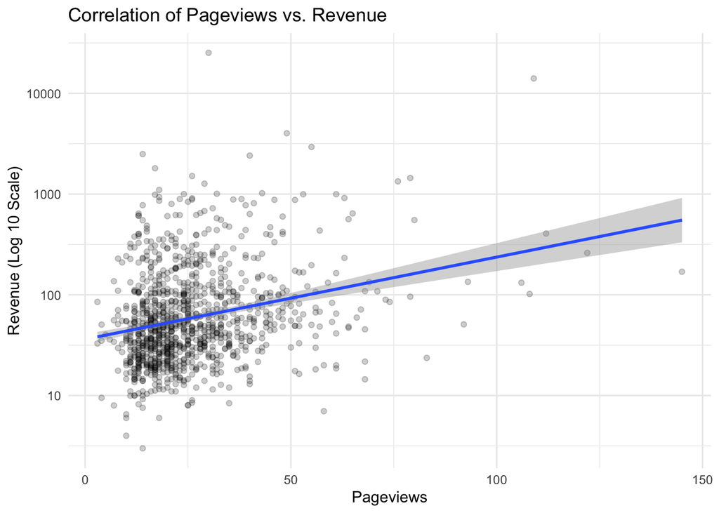

```r
ga %>%
  distinct() %>%
  filter(transactions > 0) %>%
  ggplot(aes(x = pageviews, y = totalTransactionRevenue)) +
  geom_point(alpha = 0.2) +
  theme_minimal() +
  scale_y_continuous(trans='log10') +
  geom_smooth(method = "lm", se = TRUE, formula = y ~ x) +
  labs(x = "Pageviews",
       y = "Revenue (Log 10 Scale)",
       title = "Correlation of Pageviews vs. Revenue")
```

```r
ga %>%
  filter(totalTransactionRevenue > 10000) %>%
  distinct() %>%
  head()
```

|  | date | userID | sessionID | session | pageviews | newVisits | transactions | visits | totalTransactionRevenue | browser | deviceCategory | country | region |
| --- | --- | --- | --- | --- | --- | --- | --- | --- | --- | --- | --- | --- | --- |
| 1 | 2017-07-13 | 9417857471295131045 | 1499951313 | 1 | 109 | 1 | 2 | 1 | 14060.31 | Chrome | desktop | United States | NA |
| 2 | 2017-07-18 | 9417857471295131045 | 1500404409 | 8 | 30 | NA | 2 | 1 | 25249.26 | Chrome | desktop | United States | NA |

Interestingly these two transactions from the very same user. It’s worth investigating how many visits they have done and additional transactions.

```r
ga %>%
  filter(userID == "9417857471295131045") %>%
  distinct() %>%
  arrange(desc(pageviews)) %>%
  head(n = 20)
```

|  | date | userID | sessionID | session | pageviews | newVisits | transactions | visits | totalTransactionRevenue | browser | deviceCategory | country | region |
| --- | --- | --- | --- | --- | --- | --- | --- | --- | --- | --- | --- | --- | --- |
| 1 | 2017-07-13 | 9417857471295131045 | 1499951313 | 1 | 109 | 1 | 2 | 1 | 14060.31 | Chrome | desktop | United States | NA |
| 2 | 2017-07-21 | 9417857471295131045 | 1500657634 | 10 | 76 | NA | 2 | 1 | 1337.28 | Chrome | desktop | United States | NA |
| 3 | 2017-07-20 | 9417857471295131045 | 1500576617 | 9 | 60 | NA | 0 | 1 | NA | Chrome | desktop | United States | NA |
| 4 | 2017-07-28 | 9417857471295131045 | 1501255344 | 19 | 51 | NA | 2 | 1 | 875.12 | Chrome | desktop | United States | NA |
| 5 | 2017-07-17 | 9417857471295131045 | 1500332130 | 7 | 36 | NA | 1 | 1 | 288.88 | Chrome | desktop | United States | NA |
| 6 | 2017-07-14 | 9417857471295131045 | 1500057023 | 4 | 33 | NA | 0 | 1 | NA | Chrome | desktop | United States | NA |
| 7 | 2017-07-18 | 9417857471295131045 | 1500404409 | 8 | 30 | NA | 2 | 1 | 25249.26 | Chrome | desktop | United States | NA |
| 8 | 2017-07-24 | 9417857471295131045 | 1500915986 | 12 | 15 | NA | 0 | 1 | NA | Chrome | desktop | United States | NA |
| 9 | 2017-08-01 | 9417857471295131045 | 1501616980 | 22 | 14 | NA | 0 | 1 | NA | Chrome | desktop | United States | NA |
| 10 | 2017-07-13 | 9417857471295131045 | 1499970895 | 2 | 10 | NA | 0 | 1 | NA | Chrome | desktop | United States | NA |

[output cut: 6 more lines]

```r
ga %>%
  filter(transactions > 0 & userID == "9417857471295131045") %>%
  distinct() %>%
  group_by(userID) %>%
  summarise(total = sum(totalTransactionRevenue))
```

| userID | total |
| --- | --- |
| 9417857471295131045 | 41810.85 |

This user (`9417857471295131045`) had `9` transactions over the month. and a total of `41,810.85`.

## What days of the month produced the most revenue?

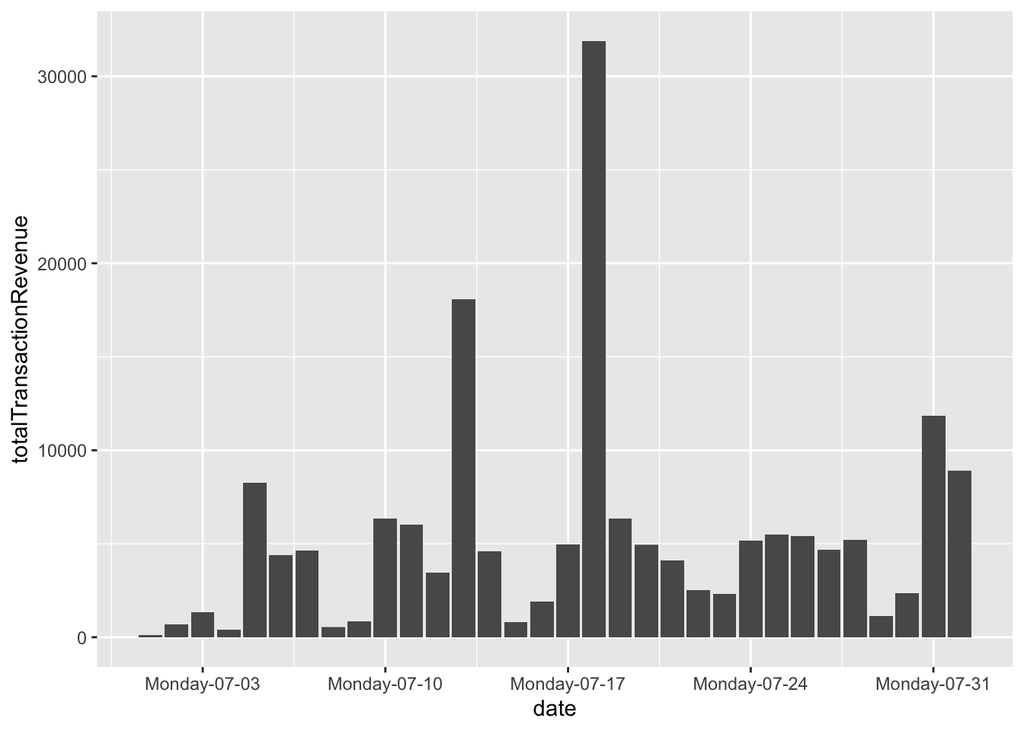

```r
ga %>%
  filter(transactions > 0) %>%
  distinct() %>%
  ggplot(aes(y = totalTransactionRevenue, x = date)) +
  geom_col() +
  scale_x_date(labels = date_format("%A-%m-%d"))
```

Based on the dates, it looks like weekend activity is a little lower and early week activity is the strongest.

### How many Users had more at least one transaction.

Determine how many users there are.

```r
ga %>%
  filter(transactions > 0) %>%
  distinct(userID) %>%
  summarise(userID = n())
```

| userID |
| --- |
| 1000 |

There are `1,000` unique (distinct) users in this dataset that completed at least one transaction. These users could have completed more than one transaction however.

# Mid Term Questions

Make sure to show intermediary data frames / aggregations / calculations that help answer the questions. Some hints have been included to assist you but you should apply the tools / knowledge gained up to this point.

## Question #1

What was the average number of product pageviews for users who did make a purchase?

**Note:** *General calculation: SUM(total_pagesviews_per_user) / COUNT(users)*

```r
ga %>%
  filter(transactions > 0) %>%
  distinct() %>%
  summarise(avg_pageviews = (sum(pageviews) / n_distinct(userID)))
```

| avg_pageviews |
| --- |
| 27.999 |

We find that users have an average of `28` page views that make a transaction.

*BigQuery Answer: 27.999*

**Note:** *This calculation represent distinct users, which takes into account users that have made more than one transaction. for example, if there was a user that had 2 sessions which resulted in two transactions, they are not counted as two users, they are counted as a single person.*

## Question #2

What was the average number of product `pageviews` for users who **did not** make a purchase?

```r
ga %>%
  filter(transactions == 0) %>%
  distinct() %>%
  summarise(avg_pageviews = (sum(pageviews) / n_distinct(userID)))
```

| avg_pageviews |
| --- |
| 4.216818 |

The average number of pageviews for users that did not purchase is `4.22`.

*Big Query Answer = 4.216817765948599*

**Note:** *This calculation represents distinct users, which takes into account users who have made more than one visit to the site that didn’t result in a transaction. This doesn’t mean the user didn’t eventually complete a transaction in another session.*

## Question #3

What was the average total transactions per user that made a purchase?

**Note:** *General calculation: SUM (total_transactions_per_user) / COUNT(userID)*

First, calculate how many transactions per user happened. The transaction field is defined as *“Total number of ecommerce transactions within the session.”* Therefore, we need to sum them to get the total per user. We can see the largest user had `9` total transactions. This was the same user with the two large sales explored above.

```r
ga %>%
  filter(transactions > 0) %>%
  distinct() %>%
  group_by(userID) %>%
  summarise(transactions = sum(transactions)) %>%
  arrange(desc(transactions))
```

| userID | transactions |
| --- | --- |
| 9417857471295131045 | 9 |
| 4260968995177655855 | 5 |
| 5584411114546174652 | 5 |
| 4178948793864037103 | 4 |
| 5215840735346366486 | 4 |
| 5772921781547143127 | 4 |
| 7567817112637547239 | 4 |
| 9240425877262756231 | 4 |
| 0014262055593378383 | 3 |
| 0376394056092189113 | 3 |

[output cut: 990 more lines]

Finally, perform the calculation dividing by the total number of distinct users that made a purchase.

```r
ga %>%
  filter(transactions > 0) %>%
  distinct() %>%
  summarise(avg_total_transactions_per_user = sum(transactions) / n_distinct(userID))
```

| avg_total_transactions_per_user |
| --- |
| 1.117 |

The average of a transaction across all users was `1.117`.

*Big Query Answer = 1.117*

## Question #4

What is the average amount of money spent per session? Here per session is the total of ‘visits’ by user.

**Note:** *General calculation: SUM(total_transactionrevenue_per_user) / SUM(total_visits_per_user)*

```r
ga %>%
  filter(transactions > 0) %>%
  distinct() %>%
  summarise(rev_per_session = sum(totalTransactionRevenue) / sum(visits))
```

| rev_per_session |
| --- |
| 157.9421 |

Average amount spent per visit is `157.94` for this month of data.

**Google Big Query** **Note**: The following is the original query from Google. It was found that the Revenue numbers didn’t match the data in the CSV. However, the above calculation is the same as what’s provided below.

```
  #standardSQL
  SELECT
  ( SUM(total_transactionrevenue_per_user) / SUM(total_visits_per_user) ) AS
  avg_revenue_by_user_per_visit
  FROM (
  SELECT
  fullVisitorId,
  SUM( totals.visits ) AS total_visits_per_user,
  SUM( totals.transactionRevenue ) AS total_transactionrevenue_per_user
  FROM
  `bigquery-public-data.google_analytics_sample.ga_sessions_*`
  WHERE
  _TABLE_SUFFIX BETWEEN '20170701' AND '20170801'
  AND
  totals.visits > 0
  AND totals.transactions >= 1
  AND totals.transactionRevenue IS NOT NULL
  GROUP BY
  fullVisitorId )
```

*BigQuery Answer = 123.65383612662943*

## Question #5

What is the total number of transactions generated per browser type ? Results should be in tabular form that shows the aggregated transactions by browser, including those that resulted in 0 transactions.

```r
ga %>%
  distinct() %>%
  dplyr::group_by(browser) %>%
  dplyr::summarise(trans = sum(transactions)) %>%
  arrange(desc(trans))
```

| browser | trans |
| --- | --- |
| Chrome | 1025 |
| Safari | 68 |
| Firefox | 13 |
| Internet Explorer | 7 |
| Edge | 2 |
| Opera | 2 |
| (not set) | 0 |
| [Use default User-agent string] LIVRENPOCHE | 0 |
| 0 | 0 |
| Amazon Silk | 0 |

[output cut: 20 more lines]

`Chome` is by far the largest browser being used, not suprising given its popularity and the fact this is a Google store.

# Regression Analysis

Determine if there is a strong relationship between two or more variables in the data.

```r
names(ga)
```

```
##  [1] "date"                    "userID"
##  [3] "sessionID"               "session"
##  [5] "pageviews"               "newVisits"
##  [7] "transactions"            "visits"
##  [9] "totalTransactionRevenue" "browser"
## [11] "deviceCategory"          "country"
## [13] "region"
```

## Logistic Regression to Predict Conversions

First, convert the `transaction` field into a binary value in a new Data Frame

```r
summary(ga$transactions)
```

```
##    Min. 1st Qu.  Median    Mean 3rd Qu.    Max.
##  0.0000  0.0000  0.0000  0.1063  0.0000  4.0000
```

```r
ga_log <- ga
ga_log$transactions[ga_log$transactions > 0] = 1
summary(ga_log$transactions)
```

```
##    Min. 1st Qu.  Median    Mean 3rd Qu.    Max.
## 0.00000 0.00000 0.00000 0.09947 0.00000 1.00000
```

```r
ga_glm <- ga_log %>%
  distinct()

model <- glm(formula = transactions ~ pageviews + deviceCategory, data = ga_glm, family = "binomial")

summary(model)
```

```
##
## Call:
## glm(formula = transactions ~ pageviews + deviceCategory, family = "binomial",
##     data = ga_glm)
##
## Deviance Residuals:
##     Min       1Q   Median       3Q      Max
## -6.2236  -0.1240  -0.1162  -0.0580   3.5002
##
## Coefficients:
##                       Estimate Std. Error z value             Pr(>|z|)
## (Intercept)          -5.127115   0.052231 -98.163 < 0.0000000000000002 ***
## pageviews             0.131686   0.002484  53.011 < 0.0000000000000002 ***
## deviceCategorymobile -1.523182   0.123298 -12.354 < 0.0000000000000002 ***
## deviceCategorytablet -1.736777   0.321921  -5.395         0.0000000685 ***
## ---
## Signif. codes:  0 '***' 0.001 '**' 0.01 '*' 0.05 '.' 0.1 ' ' 1
##
## (Dispersion parameter for binomial family taken to be 1)
##
##     Null deviance: 11234  on 74351  degrees of freedom
## Residual deviance:  7458  on 74348  degrees of freedom
## AIC: 7466
##
## Number of Fisher Scoring iterations: 8
```

https://stats.idre.ucla.edu/r/dae/logit-regression/

```r
## odds ratios and 95% CI
exp(cbind(OR = coef(model), confint(model)))
```

```
##                               OR       2.5 %      97.5 %
## (Intercept)          0.005933655 0.005348798 0.006564326
## pageviews            1.140750615 1.135246647 1.146356604
## deviceCategorymobile 0.218017035 0.170031961 0.275843946
## deviceCategorytablet 0.176086976 0.088575737 0.315530860
```

## Multiple Regression Model to Predict Transaction Revenue

Using a multiple regression model to predict the independent continuous variable revenue from other dependent variables.

```r
ga_lm <- ga %>%
  distinct()

fit1 <- lm(formula = log1p(totalTransactionRevenue) ~ pageviews, data = ga_lm)

summary(fit1)
```

```
##
## Call:
## lm(formula = log1p(totalTransactionRevenue) ~ pageviews, data = ga_lm)
##
## Residuals:
##     Min      1Q  Median      3Q     Max
## -2.6149 -0.6947 -0.2000  0.4962  5.9598
##
## Coefficients:
##             Estimate Std. Error t value            Pr(>|t|)
## (Intercept)  3.62358    0.06364  56.938 <0.0000000000000002 ***
## pageviews    0.01844    0.00212   8.697 <0.0000000000000002 ***
## ---
## Signif. codes:  0 '***' 0.001 '**' 0.01 '*' 0.05 '.' 0.1 ' ' 1
##
## Residual standard error: 1.034 on 1072 degrees of freedom
##   (73278 observations deleted due to missingness)
## Multiple R-squared:  0.06591,    Adjusted R-squared:  0.06503
## F-statistic: 75.64 on 1 and 1072 DF,  p-value: < 0.00000000000000022
```

```r
ga_lm <- ga %>%
  distinct()

fit2 <- lm(formula = log1p(totalTransactionRevenue) ~
            pageviews + session,
          data = ga_lm)

summary(fit2)
```

```
##
## Call:
## lm(formula = log1p(totalTransactionRevenue) ~ pageviews + session,
##     data = ga_lm)
##
## Residuals:
##     Min      1Q  Median      3Q     Max
## -3.8689 -0.6778 -0.1826  0.5001  5.8352
##
## Coefficients:
##             Estimate Std. Error t value             Pr(>|t|)
## (Intercept) 3.528683   0.064782  54.470 < 0.0000000000000002 ***
## pageviews   0.018057   0.002090   8.641 < 0.0000000000000002 ***
## session     0.028875   0.004969   5.811         0.0000000082 ***
## ---
## Signif. codes:  0 '***' 0.001 '**' 0.01 '*' 0.05 '.' 0.1 ' ' 1
##
## Residual standard error: 1.018 on 1071 degrees of freedom
##   (73278 observations deleted due to missingness)
## Multiple R-squared:  0.09445,    Adjusted R-squared:  0.09276
## F-statistic: 55.86 on 2 and 1071 DF,  p-value: < 0.00000000000000022
```

```r
ga_lm <- ga %>%
  distinct()

fit3 <- lm(formula = log1p(totalTransactionRevenue) ~
            pageviews + session + deviceCategory,
          data = ga_lm)

summary(fit3)
```

```
##
## Call:
## lm(formula = log1p(totalTransactionRevenue) ~ pageviews + session +
##     deviceCategory, data = ga_lm)
##
## Residuals:
##     Min      1Q  Median      3Q     Max
## -3.7604 -0.6769 -0.1682  0.4875  5.7949
##
## Coefficients:
##                       Estimate Std. Error t value             Pr(>|t|)
## (Intercept)           3.586930   0.065449  54.805 < 0.0000000000000002 ***
## pageviews             0.017851   0.002072   8.614 < 0.0000000000000002 ***
## session               0.027397   0.004935   5.551         0.0000000358 ***
## deviceCategorymobile -0.476884   0.109203  -4.367         0.0000138247 ***
## deviceCategorytablet -0.476479   0.282053  -1.689               0.0914 .
## ---
## Signif. codes:  0 '***' 0.001 '**' 0.01 '*' 0.05 '.' 0.1 ' ' 1
##
## Residual standard error: 1.009 on 1069 degrees of freedom
##   (73278 observations deleted due to missingness)
## Multiple R-squared:  0.1122, Adjusted R-squared:  0.1089
## F-statistic: 33.79 on 4 and 1069 DF,  p-value: < 0.00000000000000022
```

## Anova Test for Fitness

anova model comparison https://bookdown.org/ndphillips/YaRrr/comparing-regression-models-with-anova.html

R2 vs Adjusted R2 : https://www.statisticshowto.com/adjusted-r2/

```r
anova(fit1, fit2)
```

|  | Res.Df | RSS | Df | Sum of Sq | F | Pr(>F) |
| --- | --- | --- | --- | --- | --- | --- |
| 1 | 1072 | 1145.135 | NA | NA | NA | NA |
| 2 | 1071 | 1110.136 | 1 | 34.99862 | 33.76479 | 0.00000000819618 |

```r
anova(fit2, fit3)
```

|  | Res.Df | RSS | Df | Sum of Sq | F | Pr(>F) |
| --- | --- | --- | --- | --- | --- | --- |
| 1 | 1071 | 1110.136 | NA | NA | NA | NA |
| 2 | 1069 | 1088.335 | 2 | 21.80107 | 10.70688 | 0.00002488989 |

```r
anova(fit1, fit3)
```

|  | Res.Df | RSS | Df | Sum of Sq | F | Pr(>F) |
| --- | --- | --- | --- | --- | --- | --- |
| 1 | 1072 | 1145.135 | NA | NA | NA | NA |
| 2 | 1069 | 1088.335 | 3 | 56.79969 | 18.59686 | 0.000000000009179598 |